# What Can We Learn From Unenforced Laws?.

Of the 700 million[^1] girls around the globe who married under 18, one third were from India. When you ask Indian parents why they would marry their daughters off so young, they describe the need to accept the first “good” proposal that comes their way. This need is often rooted in poverty[^2], the desire to pay lower dowries, or social expectations and norms about the appropriate timing of marriage for girls.

Legislation designed to eradicate deeply rooted harmful customs is often resisted by community leaders, ignored by individuals, and unenforced by local enforcement officers. In fact, many legal changes meant to curtail participation in customs such as early marriage remain unenforced political statements, partly explaining the persistence of these customs today. But does the lack of enforcement necessarily imply that these policies remain ‘dead letters’?

In my job market paper, I examine how the Child Marriage Restraint Act (Amendment 1978) contributed to a decrease in early marriage for girls in India-despite little indication of enforcement. I provide evidence that differences in enforcement capacities did not drive the policy’s success. Instead, I argue that the ban’s announcement had the potential to change behavior by acting as a signal for social expectations.

## What was the Child Marriage Restraint Act?

In 1974, the Indian Ministry of Health and Family Planning issued a mass announcement predicting a 15 percent decrease in birth rates if the minimum age of marriage for women was increased to 18 years. This statement was followed by the enactment of the 1978 amendment to the Child Marriage Restraint Act (CMRA), which increased the legal age of marriage for women from 15 to 18 and 18 to 21 years for men.

## Estimating the Impact of the CMRA Amendment

Estimating the impact of the increase in the legal age of marriage is challenging because the policy was applicable throughout the country at once, disallowing the use of time or geographical variation. Instead, I use data from the Demographic and Health Survey[^3] to implement a quasi-experimental framework in which I estimate the causal effect of the policy by exploiting two sources of variation:

- A woman’s age when the policy was enacted, estimated using her year of birth. I consider women younger than 15 at policy enactment as treated because they had to wait three extra years to marry legally. Women older than 18 are not exposed to the ban and comprise my control group; they can legally marry both before and after the amendment.
- The strength of early marriage norms in her marriage market. I construct 130 marriage markets using unique combinations of state of birth, religion, and caste. For each market, I measure the strength of early marriage norms as the proportion of women who married underage prior to the policy. Approximately 95 percent of women marry within their caste and religion, and 91 percent marry within their state of birth, so concerns about selection into marriage markets with different norms are low.

Substantial variations existed in the prevalence of pre-policy early marriage norms across marriage markets, indicating differences in traditions and stigmas. The strength of the norms would potentially impact the effectiveness and acceptability of the ban across markets, and therefore, behavior.

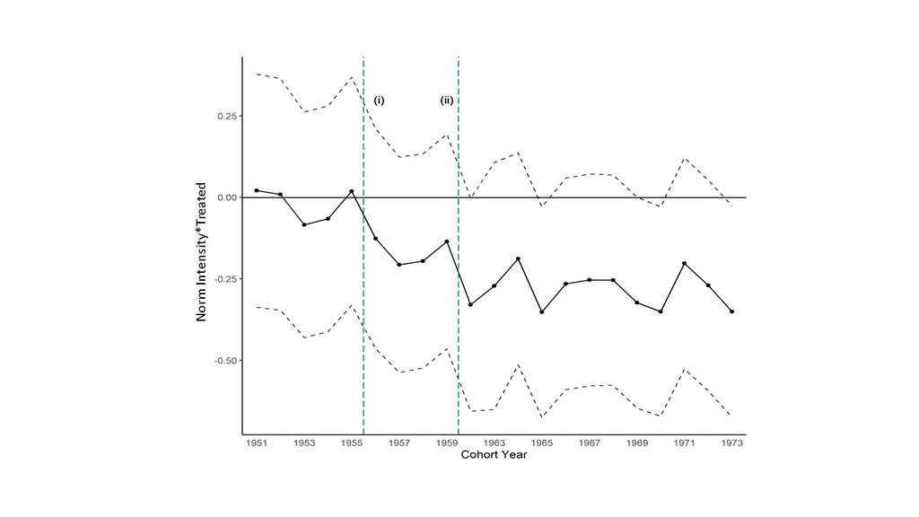

Figure 1: DHS 1998 and 2005. (i) represents announcement and (ii) represents enactment of the policy.

Thus, my method compares treated and untreated women across marriage markets with differential social norms. The risk of using this approach is that pre-existing differential trends across marriage markets may drive the effect attributed to the policy change. As a verification that the impact is not merely picking up pre-policy trends, I show in Figure 1 that the probability of early marriage is not systematically different across markets for treated versus control groups before policy announcement (denoted by the vertical line (i)).

## Did the CMRA amendment work?

Yes. The policy enactment induced a 7.8 and 5.1 percent reduction in the probability of marrying under 18 and 15, respectively, at the average early marriage norm intensity. This decrease in early marriage occurs for both literate and illiterate women in urban areas-regions with greater awareness of the ban.

My results suggest multiple related findings:

- There is no change in the probability of ever marrying, for women.
- There is a corresponding increase in marriage likelihood at the ages 18, 19, and 20.
- As cohabitation closely follows marriage in India, the probability of cohabiting with a partner before attaining the age of 18 also decreases significantly.
- The policy enactment did not affect the age of marriage decision for men.

The results lead to the question of whether girls who delayed marriage were any worse off in terms of their marital outcomes? I do not find evidence that girls who delayed marriage had less say in who they married, married men who they knew for less time, or men who lived further away (indicating an expansion of the search for marital partners).

## Mechanisms

The most natural explanation for any policy having its intended effect is enforcement. Interestingly, the amendment did not increase the severity of punishment for convicted offenders (three months of jail time, a 1000 Rupee fine, or both), nor were marriages involving underage brides or grooms considered invalid. Investigations into public complaints of possible underage marriages were restricted to a window of a year of the union taking place, and marriage registrations (upon which evidence of legal age is required) were also not mandatory at the time. There is little the government could do to disincentivize non-abiders effectively.

I provide evidence that differential political leadership or police capacities do not drive abidance behavior across marriage markets. I also control for and rule out the influence of differential trends, sex ratios, income shocks, and levels of development.

So why then should the CMRA amendment affect behavior? Without enforceable sanctions, the law can only influence behavior away from a custom by changing individuals’ expectations in a coordinated way. In other words, the law should provide a strong signal of other individuals’ behavior (or the norm). The late 1970s were characterized by very active governance with the implementation of several strictly enforced social projects, including the notorious male sterilization campaign. This suggests that the ban’s perceived enforcement was high, simply because the government had proven its intention and capacity for stringent enforcement. A heightened perception of enforcement had the potential to highlight further, and make credible, the early marriage ban upon announcement.

## What do we learn?

The results offer exciting insight into the interplay between policy, social norms, and harmful customs. The research provides suggestive evidence for the law’s non-sanctionary arm (an often-overlooked aspect of policy implementation and design). It highlights the idea that social norms are not expected to have symmetrical effects on the age of marriage decisions for both men and women. This idea has been underscored by earlier research[^4], which suggests that social norms regarding the ideal age of marriage in India are binding for girls, but not for boys.

Finally, it is essential to point out that the results by no means suggest that the mere announcement of a policy change is always sufficient for affecting individual behavior. Instead, policy awareness and a high perception of enforcement cultivated through active governance can provide credibility to even unenforced legislation changes.

[^1]: UNICEF: https://www.unicef.org/media/files/Child_Marriage_Report_7_17_LR..pdf
[^2]: https://onlinelibrary.wiley.com/doi/abs/10.3982/ECTA15505
[^3]: https://dhsprogram.com/
[^4]: https://econpapers.repec.org/article/eeewdevel/v_3a47_3ay_3a2013_3ai_3ac_3ap_3a1-15.htm